# R Notebook

```r
library(tidyverse)
library(infer)
library(janitor)
```

```r
nice <- read_csv("data/nice.csv")
algarve <- read_csv("data/algarve.csv")
corfu <- read_csv("data/corfu.csv")
florence <- read_csv("data/florence.csv")
```

## Independent Samples

Null hypothesis The mean price of lets in the Algarve is not different to the mean price of lets in Nice
$$H_0: µ_{mean\ price\ lets\ algarve} =\ µ_{mean\ price\ lets\ nice}$$

```r
apart_prices <- bind_rows(nice = nice,
                          algarve = algarve,
                          .id = "location")

apart_prices
```

| location | ...1 | price |
| --- | --- | --- |
| nice | 1 | 1594 |
| nice | 2 | 1537 |
| nice | 3 | 1565 |
| nice | 4 | 1477 |
| nice | 5 | 2072 |
| nice | 6 | 1608 |
| nice | 7 | 1482 |
| nice | 8 | 2249 |
| nice | 9 | 2238 |
| nice | 10 | 1761 |

[output cut: 90 more lines]

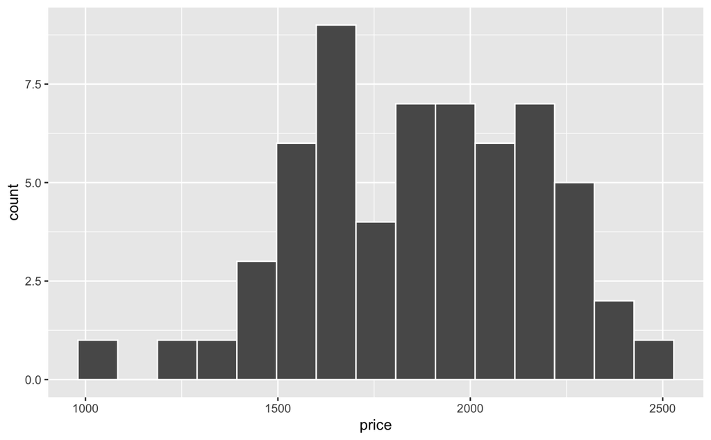

```r
nice_dist <- apart_prices %>%
  filter(location == "nice")

nice_dist %>%
  ggplot(aes(x = price)) +
  geom_histogram(col = "white", bins = 15)
```

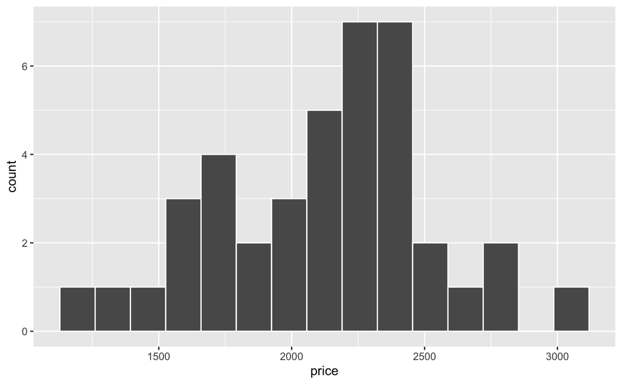

```r
algrave_dist <- apart_prices %>%
  filter(location == "algarve")

algrave_dist %>%
  ggplot(aes(x = price)) +
  geom_histogram(col = "white", bins = 15)
```

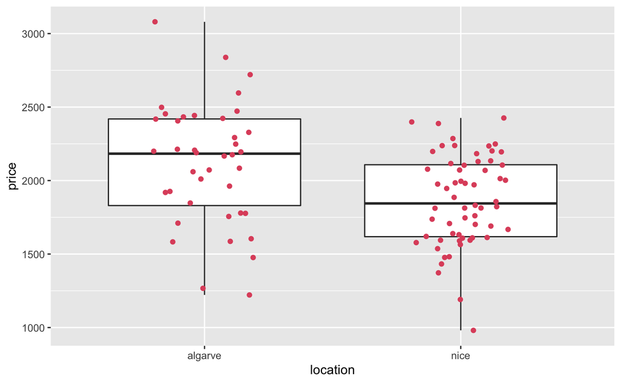

```r
apart_prices %>%
  ggplot(aes(x = location,
             y = price)) +
  geom_boxplot() +
  geom_jitter(width = 0.2, colour = 2)
```

```r
null_distribution <- apart_prices %>%
  specify(price ~ location) %>%  # is the y-axis affected by the x-axis
  #specify(response = price, explanatory = location) alternative to above
  hypothesise(null = "independence") %>%
  generate(reps = 1000, type = "permute") %>%
  calculate(stat = "diff in means", order = c("algarve", "nice"))

null_distribution
```

```
Response: price (numeric)
Explanatory: location (factor)
Null Hypothesis: independence
```

| replicate | stat |
| --- | --- |
| 1 | -45.3500000 |
| 2 | 198.0250000 |
| 3 | 9.6916667 |
| 4 | 30.1500000 |
| 5 | -7.9750000 |
| 6 | -69.5166667 |
| 7 | -131.3916667 |
| 8 | -27.7250000 |
| 9 | 44.6500000 |
| 10 | -119.8083333 |

[output cut: 990 more lines]

```r
observed_stat <- apart_prices %>%
  specify(price ~ location) %>%
  calculate(stat = "diff in means", order = c("algarve", "nice"))

observed_stat
```

```
Response: price (numeric)
Explanatory: location (factor)
```

| stat |
| --- |
| 251.4 |

On average, there is a difference of 251.4 between the algarve and nice

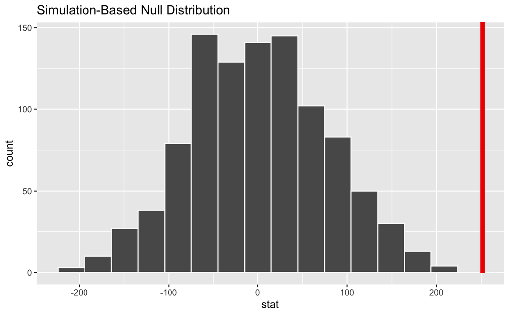

```r
null_distribution %>%
  visualise(bins = 15) +
  shade_p_value(obs_stat = observed_stat, direction = "right")
```

```r
p_value <- null_distribution %>%
  get_p_value(obs_stat = observed_stat, direction = "right")

p_value
```

[output not shown]

Never, ever, ever, ever, ever report p = 0 p < 0.0001

Corfu and Florence Task

alpha = 0.05

Null hypothesis There is no significant difference between the mean let prices in Florence and Corfu
$$H_0: µ_{mean\ price\ lets\ florence} =\ µ_{mean\ price\ lets\ corfu}$$

Alternative hypothesis The mean let prices in Florence are significantly lower than those in Corfu
$$H_1: µ_{mean\ price\ lets\ florence} <\ µ_{mean\ price\ lets\ corfu}$$

```r
apartment_prices <- bind_rows(florence = florence,
                              corfu = corfu,
                              .id = "location")

apartment_prices
```

[output not shown]

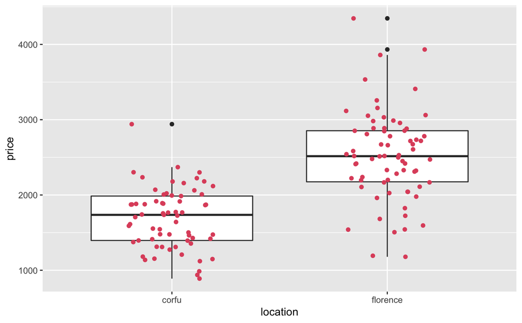

```r
apartment_prices %>%
  ggplot(aes(x = location,
             y = price)) +
  geom_boxplot() +
  geom_jitter(width = 0.2, colour = 2)
```

```r
fc_null_distribution <- apartment_prices %>%
  specify(price ~ location) %>%
  hypothesise(null = "independence") %>%
  generate(reps = 5000, type = "permute") %>%
  calculate(stat = "diff in means", order= c("florence", "corfu"))

fc_null_distribution
```

```
Response: price (numeric)
Explanatory: location (factor)
Null Hypothesis: independence
```

| replicate | stat |
| --- | --- |
| 1 | -25.8153846 |
| 2 | 42.5153846 |
| 3 | -61.4494505 |
| 4 | 267.1197802 |
| 5 | -91.8615385 |
| 6 | -8.7846154 |
| 7 | -44.3000000 |
| 8 | 97.4648352 |
| 9 | 150.3967033 |
| 10 | 2.6384615 |

[output cut: 990 more lines]

```r
fc_observed_stat <- apartment_prices %>%
  specify(price ~ location) %>%
  calculate(stat = "diff in means", order = c("florence", "corfu"))

fc_observed_stat
```

```
Response: price (numeric)
Explanatory: location (factor)
```

| stat |
| --- |
| 824.1802 |

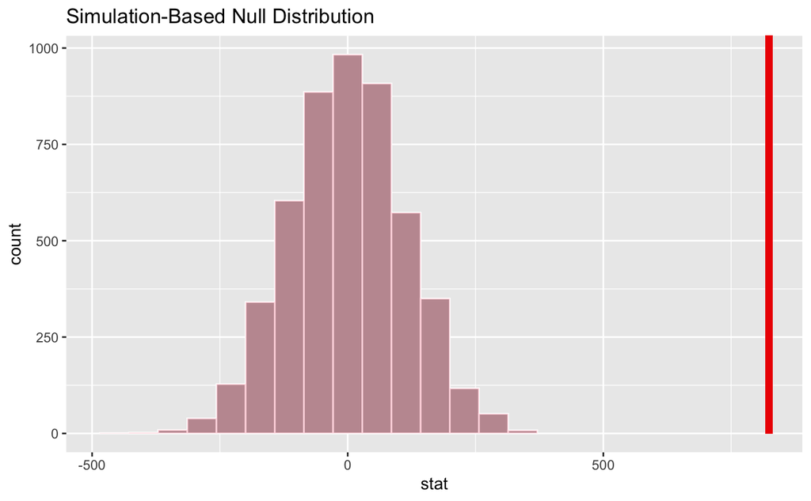

```r
fc_null_distribution %>%
  visualise(bins = 15) +
  shade_p_value(obs_stat = fc_observed_stat, direction = "left")
```

```r
p_value <- fc_null_distribution %>%
  get_p_value(obs_stat = fc_observed_stat, direction = "left")

p_value
```

| p_value |
| --- |
| 1 |

Paired Samples (aka dependent)

```r
textbooks <- read_csv("data/ucla_textbooks_f18.csv")
```

> Is there a significant difference on *average* between the prices for *new texts* offfered by the *campus bookstore* vs the prices available for the same texts on *Amazon*?

Null hypo
$$H_0: µ_{diff\ new} =\ 0$$

Alt hypo
$$H_1:µ_{diff\ new} \neq\ 0$$

[output not shown]

[output cut: 58 more lines]

```r
null_dist <- books_diff %>%
  specify(response = diff_new) %>%
  hypothesise(null = "point", mu = 0) %>%
  generate(reps = 5000, type = "bootstrap") %>%
  calculate(stat = "mean")

null_dist
```

```
Response: diff_new (numeric)
Null Hypothesis: point
```

| replicate | stat |
| --- | --- |
| 1 | -2.909705882 |
| 2 | -1.024117647 |
| 3 | 1.219117647 |
| 4 | 0.542647059 |
| 5 | -1.082794118 |
| 6 | 1.775147059 |
| 7 | -1.464705882 |
| 8 | 1.159411765 |
| 9 | -0.146029412 |
| 10 | 0.863529412 |

[output cut: 990 more lines]

```r
observed_stat <- books_diff %>%
  specify(response = diff_new) %>%
  calculate(stat = "mean")

observed_stat
```

```
Response: diff_new (numeric)
```

| stat |
| --- |
| 3.583235 |

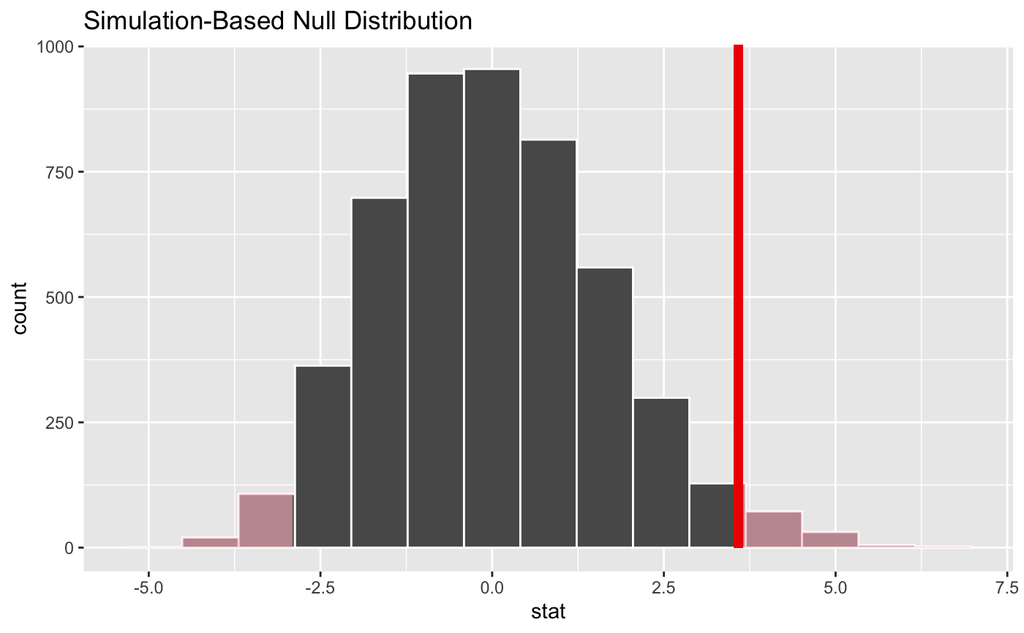

```r
null_dist %>%
  visualise() +
  shade_p_value(obs_stat = observed_stat, direction = "both")
```

```r
p_value <- null_dist %>%
  get_p_value(obs_stat = observed_stat, direction = "both")

p_value
```

| p_value |
| --- |
| 0.048 |

Our study suggests that the prices in the UCLA book shop are significantly different from the prices on Amazon, on avergae (p = 0.048)

Task: On average, are the prices of used course texts *lower on Amazon* than at the campus bookstore?

alpha = 0.05

Null hypo
$$H_0: µ_{diff\ used\ texts\ } =\ 0$$

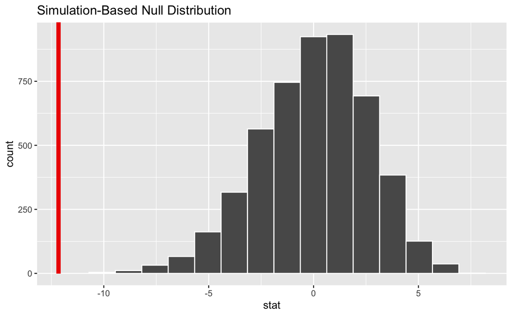

```r
books <- textbooks %>%
  mutate(diff_used = amazon_used - bookstore_used) %>%
  filter(!is.na(diff_used))

used_null_dist <- books %>%
  specify(response = diff_used) %>%
  hypothesise(null = "point", mu = 0) %>%
  generate(reps = 5000, type = "bootstrap") %>%
  calculate(stat = "mean")

used_observed_stat <- books %>%
  specify(response = diff_used) %>%
  calculate(stat = "mean")

used_null_dist %>%
  visualise() +
  shade_p_value(obs_stat = used_observed_stat, direction = "left")
```

```r
used_p_value <- null_dist %>%
  get_p_value(obs_stat = used_observed_stat, direction = "left")
used_p_value
```

| p_value |
| --- |
| 0 |

We would like to test whether the proportion of Obama voters who were women and the proportion of Romney voters who were women is significantly different (at a significance level α=0.05).

[output not shown]

[output cut: 990 more lines]

Null hypo
$$H_0: π_{women\ for\ Obama\ } - π_{women\ for\ Romney} = 0$$

Alt hypo
$$H_1: π_{women\ for\ Obama\ } - π_{women\ for\ Romney} \neq \ 0$$

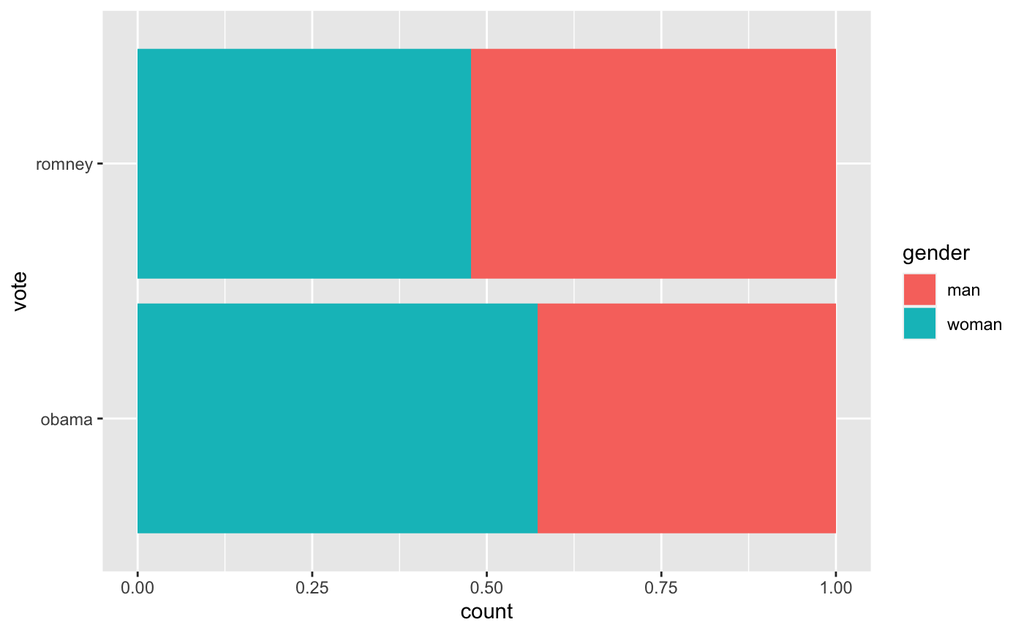

```r
ggplot(poll, aes(x = vote, fill = gender)) +
  geom_bar(position = "fill") +
  coord_flip()
```

```r
observed_stat_poll <- poll %>%
  specify(gender ~ vote, success = "woman") %>%
  calculate(stat = "diff in props", order = c("obama", "romney"))

observed_stat_poll
```

```
Response: gender (factor)
Explanatory: vote (factor)
```

| stat |
| --- |
| 0.09481102 |

```r
poll_null_dist <- poll %>%
  specify(gender ~ vote, success = "woman") %>%
  hypothesise(null = "independence") %>%
  generate(reps = 5000, type = "permute") %>%
  calculate(stat = "diff in props", order = c("obama", "romney"))
```

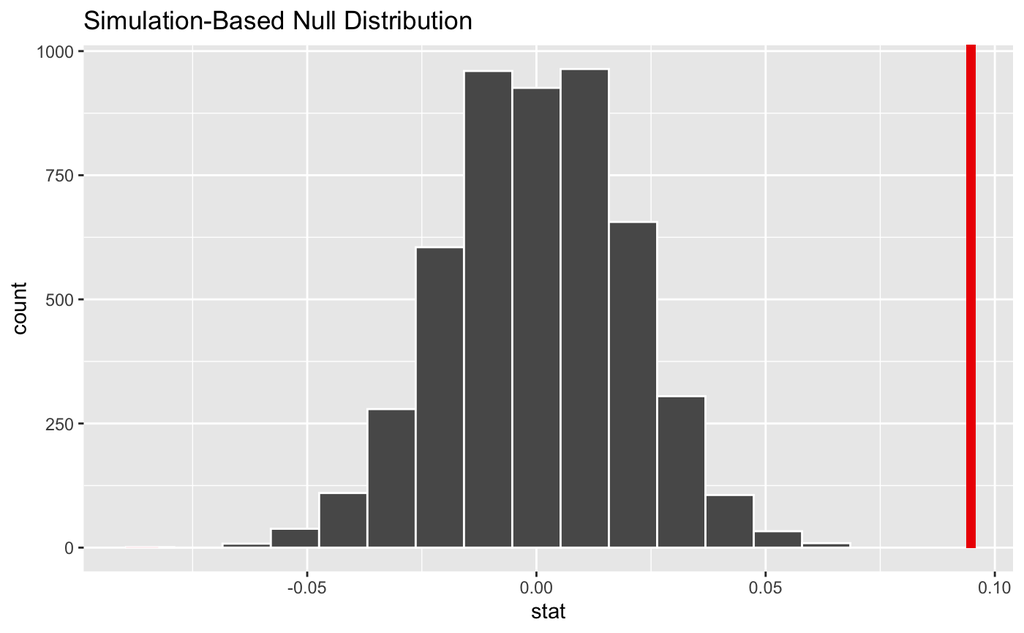

```r
poll_null_dist %>%
  visualise() +
  shade_p_value(obs_stat = observed_stat_poll, direction = "both")
```

```r
p_val <- poll_null_dist %>%
  get_p_value(obs_stat = observed_stat_poll, direction = "both")
p_val
```

| p_value |
| --- |
| 0 |